# Week 2: Importing and Manipulating Data I

This week we will be reading in a dataset, organizing it within R, and performaing a few basic functions to get a sense of the dataset.

We’ll start by setting our working directory and reading in the dataset

```r
setwd("U:/LOCKED/arthropod_data")#Yours may not be the "U:" drive, make sure you enter the correct letter
commDat=as.data.frame(read.csv("commComp_2000.csv",na.strings=c("","NA")))#The na.strings command means that any blank or NA cells will be given a value of NA. We're making it a data.frame so that it differentiates between strings (i.e. words) and numbers
```

A useful function for getting an idea of how your dataset is structured is ‘head’

```r
head(commDat)
```

```
##                      X       Order        Family         Genus Species
## 1   Fisheye Leafhopper   Hemiptera  Cicadellidae          <NA>    <NA>
## 2          Blotch mine Lepidoptera   Lyonetiidae          <NA>    <NA>
## 3           Stem borer  Coleoptera   Buprestidae          <NA>    <NA>
## 4         black Weevil  Coleoptera  Cuculionidae          <NA>    <NA>
## 5 serpentine Leaf Mine Lepidoptera Gracillaridae Phyllocnistis    <NA>
## 6             red Mite       Acari  Erythraeidae          <NA>    <NA>
##   Subspecies fre1 fre2 fre3 fre4 fre5 fre6 fre7 fre8 fre9 fre10 fone1
## 1       <NA>    4    0    9    5    5    1    5    6   12    12     5
## 2       <NA>   31   17   29   33    9   24   45   30   18    23     9
## 3       <NA>    1    0    0    0    0    1    0    0    0     0     0
## 4       <NA>    1    0    0    0    0    0    0    0    0     0     0
## 5       <NA>    6    7   17    9   12   18    7   27    0     5     2
## 6       <NA>    1    0    0    0    0    0    0    0    0     0     0
##   fone2 fone3 fone4 fone5 fone6 fone7 fone8 fone9 fone10 bc1 bc2 bc3 bc4
```

[output cut: 20 more lines]

Let’s give the first column a name

```r
colnames(commDat)=c("ArthroID",colnames(commDat[,-1]))
head(commDat)#you can see the first column now has a name
```

```
##               ArthroID       Order        Family         Genus Species
## 1   Fisheye Leafhopper   Hemiptera  Cicadellidae          <NA>    <NA>
## 2          Blotch mine Lepidoptera   Lyonetiidae          <NA>    <NA>
## 3           Stem borer  Coleoptera   Buprestidae          <NA>    <NA>
## 4         black Weevil  Coleoptera  Cuculionidae          <NA>    <NA>
## 5 serpentine Leaf Mine Lepidoptera Gracillaridae Phyllocnistis    <NA>
## 6             red Mite       Acari  Erythraeidae          <NA>    <NA>
##   Subspecies fre1 fre2 fre3 fre4 fre5 fre6 fre7 fre8 fre9 fre10 fone1
## 1       <NA>    4    0    9    5    5    1    5    6   12    12     5
## 2       <NA>   31   17   29   33    9   24   45   30   18    23     9
## 3       <NA>    1    0    0    0    0    1    0    0    0     0     0
## 4       <NA>    1    0    0    0    0    0    0    0    0     0     0
## 5       <NA>    6    7   17    9   12   18    7   27    0     5     2
## 6       <NA>    1    0    0    0    0    0    0    0    0     0     0
##   fone2 fone3 fone4 fone5 fone6 fone7 fone8 fone9 fone10 bc1 bc2 bc3 bc4
```

[output cut: 20 more lines]

Let’s get an idea of what kinds of arthropods we have. We’ll start by looking at which Orders are present:

```r
summary(commDat$Order)
```

```
##         Acari       Araneae    Coleoptera    Dermaptera       Diptera
##             2            14            17             1             8
##     Hemiptera   Hymenoptera   Lepidoptera Microcoryphia    Neuroptera
##            34            11             7             1             1
##       Odonata     Opiliones    Orthoptera  Thysanoptera
##             1             1             4             1
```

The summary() function lists each level of a categorical variable and the number of occurrences for each level. The $ allows you to specify a column in a data.frame by it’s name. This would have been equivalent to typing >summary(commDat[,2]), i.e. column 2 of commDat (try it).

Applying the summary function to continuous data, like the abundances of each OTU on freemont tree #1, gives you info on the distribution of those data:

```r
summary(commDat$fre1)
```

```
##    Min. 1st Qu.  Median    Mean 3rd Qu.    Max.
##   0.000   0.000   0.000   0.495   0.000  31.000
```

Anyway, looks like we have quite a few true bug species (Hemiptera), beetles (Coleoptera), spiders (Araneae) and bees/wasps/ants (Hymenoptera). 6/14 orders in this dataset only have one representative.

As is common with many arthropod datasets, few are ID’d below family. Let’s get an idea of the taxonomic resolution of the dataset:

```r
summary(commDat$Genus)
```

```
##        Aceria        Adalia     Alsophila    Anacampsis    Anthocorus
##             1             2             1             1             1
##    Apateticus    Brochymena  Chaitophorus    Coccinella    Euschistus
##             1             1             2             1             1
##       Formica     Gypsonoma      Harmonia    Hippodamia    Melanoplus
##             1             1             1             1             1
##    Misumenops     Oecanthus     Pemphigus Phyllocnistis   Phyllocolpa
##             2             1             3             1             1
##       Podisus      Talavera     Thecabius          NA's
##             1             1             2            74
```

```r
length(commDat$Genus[!is.na(commDat$Genus)]=="TRUE")#This tells us the total number of commDat$Genus values that are not NA
```

```
## [1] 29
```

```r
length(commDat$Genus[!is.na(commDat$Genus)]=="TRUE")/length(commDat$Genus)#Or the proportion of arthropods keyed to Genus
```

```
## [1] 0.2816
```

We can see that 28%, or 29/103 OTUs are keyed out to Genus. Go ahead and do the same for Species.

OK, let’s get an idea of relative abundances of different OTUs and higher taxonomic orders.

First, let’s just do a rank-abundance plot for the first tree.

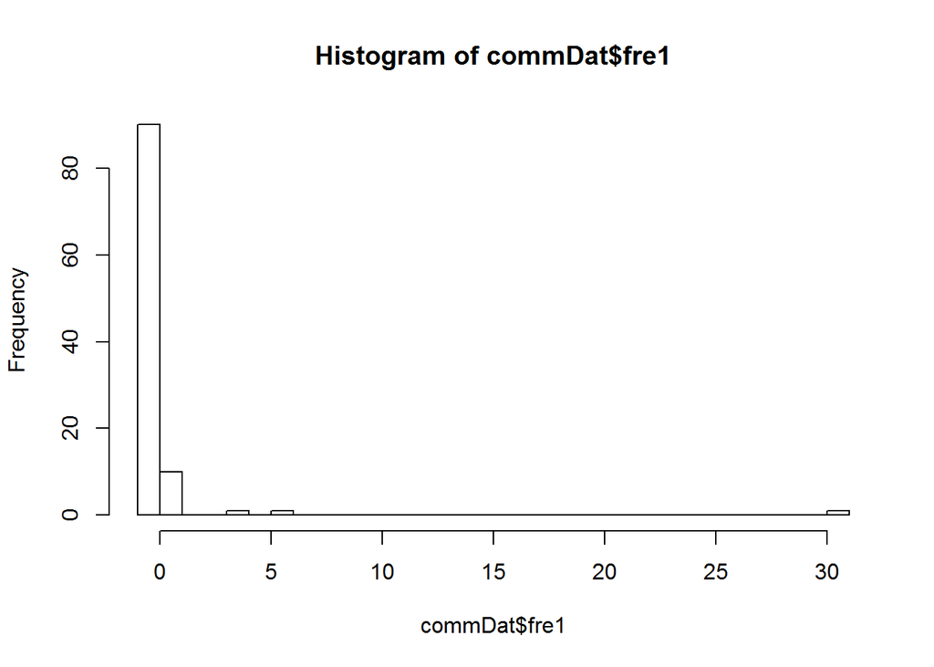

```r
hist(commDat$fre1,breaks=c(-1:max(commDat$fre1)))
```

We can see that most of the OTUs in the dataset are not present on this tree, and most species that are present are represented by a single individual.

What species is so abundant?

```r
commDat$ArthroID[commDat$fre1==max(commDat$fre1)]
```

```
## [1] Blotch mine
## 103 Levels: 2spot LBB Adalia bipunctata Andrenid ... white Salticid
```

Now let’s see what these rank abundance curves look like when we take the total abundance of each OTU across all trees.

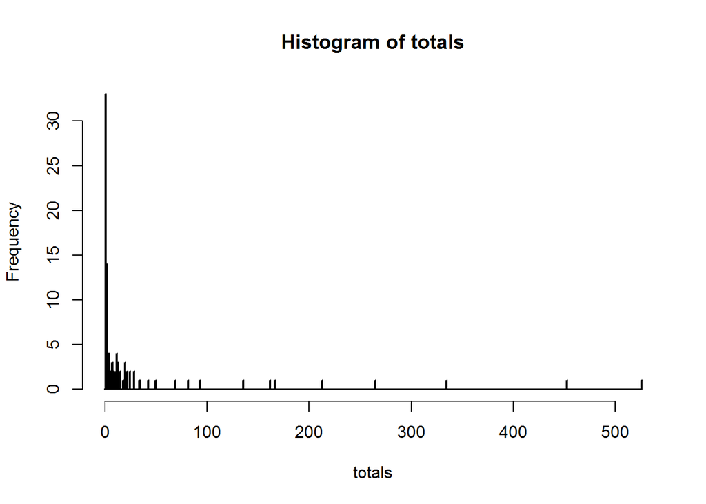

```r
totals=rowSums(commDat[,-c(1:6)])
hist(totals,breaks=c(-1:max(totals)))
```

We used the function rowsums() above. This is an example of a function that applies another function (sum) to, in this case, all rows of a dataset. We can do the same thing by using the apply() function:

```r
totals1=apply(commDat[,-c(1:6)],1,sum)#We are applying the function sum() to all rows (1=rows,2=columns) of our dataframe commDat excluding the first six rows; that is how this line can be read
totals1#you can see that this is the same as "totals" above
```

```
##   [1] 167 453  11   1 213   8  43  50   1  20 162  82  93  35   4   8  15
##  [18]   6  13  12  69  22  13  11   1   1  15   1  13   2  18  20   1  12
##  [35]   1   1   7   5   1   2   1  22   1  29  25   3  12   1   8   4  25
##  [52]  34   1   3  12  20   4  29   1 136   7   2   2   2   1   1   1 335
##  [69]   2   4   9   5 526   1   2   2   9   2   3   1   1   6   2   1   1
##  [86]   2   2   2   1 265   1   1   1   3   2   1   1   7   1   1   1   1
## [103]   1
```

The benefit of knowing how to use the apply() function is that there are only a few pre-existing functions like rowSums. For example, if you wanted to know the variance of abundances across trees for each OTU, there is no function called “rowVar” that will do that for you. But, you can use apply and the existing function var():

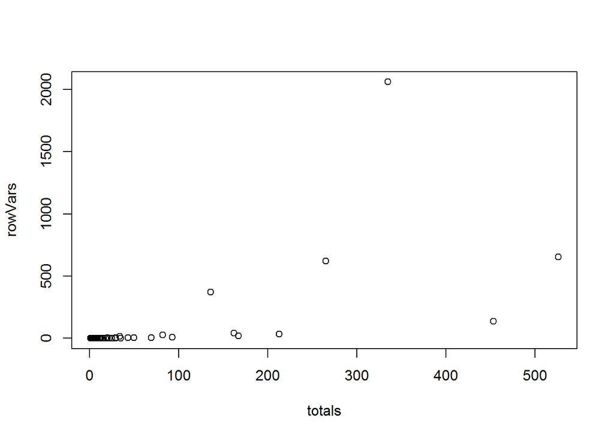

```r
rowVars=apply(commDat[,-c(1:6)],1,var)
plot(totals,rowVars)
```

That’s it for this week. Next week we’ll learn how to write our own functions to incorporate into apply().